# Risk Factor Analysis

## Outcome Variable

**Outcome Variable:** stunted

## Predictor Variables

**Intervention Variable:** anywast06

**Adjustment Set:**

unadjusted

## Stratifying Variables

The analysis was stratified on these variable(s):

- agecat
- studyid
- country

## Data Summary

| agecat | studyid | country | anywast06 | stunted | n_cell | n |
| --- | --- | --- | --- | --- | --- | --- |
| Birth | ki0047075b-MAL-ED | BANGLADESH | 0 | 0 | 163 | 255 |
| Birth | ki0047075b-MAL-ED | BANGLADESH | 0 | 1 | 35 | 255 |
| Birth | ki0047075b-MAL-ED | BANGLADESH | 1 | 0 | 47 | 255 |
| Birth | ki0047075b-MAL-ED | BANGLADESH | 1 | 1 | 10 | 255 |
| Birth | ki0047075b-MAL-ED | BRAZIL | 0 | 0 | 157 | 191 |
| Birth | ki0047075b-MAL-ED | BRAZIL | 0 | 1 | 21 | 191 |
| Birth | ki0047075b-MAL-ED | BRAZIL | 1 | 0 | 13 | 191 |
| Birth | ki0047075b-MAL-ED | BRAZIL | 1 | 1 | 0 | 191 |
| Birth | ki0047075b-MAL-ED | INDIA | 0 | 0 | 120 | 206 |
| Birth | ki0047075b-MAL-ED | INDIA | 0 | 1 | 24 | 206 |
| Birth | ki0047075b-MAL-ED | INDIA | 1 | 0 | 53 | 206 |
| Birth | ki0047075b-MAL-ED | INDIA | 1 | 1 | 9 | 206 |
| Birth | ki0047075b-MAL-ED | NEPAL | 0 | 0 | 128 | 173 |
| Birth | ki0047075b-MAL-ED | NEPAL | 0 | 1 | 13 | 173 |
| Birth | ki0047075b-MAL-ED | NEPAL | 1 | 0 | 27 | 173 |
| Birth | ki0047075b-MAL-ED | NEPAL | 1 | 1 | 5 | 173 |
| Birth | ki0047075b-MAL-ED | PERU | 0 | 0 | 245 | 286 |
| Birth | ki0047075b-MAL-ED | PERU | 0 | 1 | 30 | 286 |
| Birth | ki0047075b-MAL-ED | PERU | 1 | 0 | 8 | 286 |
| Birth | ki0047075b-MAL-ED | PERU | 1 | 1 | 3 | 286 |
| Birth | ki0047075b-MAL-ED | SOUTH AFRICA | 0 | 0 | 209 | 261 |
| Birth | ki0047075b-MAL-ED | SOUTH AFRICA | 0 | 1 | 21 | 261 |
| Birth | ki0047075b-MAL-ED | SOUTH AFRICA | 1 | 0 | 25 | 261 |
| Birth | ki0047075b-MAL-ED | SOUTH AFRICA | 1 | 1 | 6 | 261 |
| Birth | ki0047075b-MAL-ED | TANZANIA, UNITED REPUBLIC OF | 0 | 0 | 100 | 123 |
| Birth | ki0047075b-MAL-ED | TANZANIA, UNITED REPUBLIC OF | 0 | 1 | 17 | 123 |
| Birth | ki0047075b-MAL-ED | TANZANIA, UNITED REPUBLIC OF | 1 | 0 | 5 | 123 |
| Birth | ki0047075b-MAL-ED | TANZANIA, UNITED REPUBLIC OF | 1 | 1 | 1 | 123 |
| Birth | ki1000108-CMC-V-BCS-2002 | INDIA | 0 | 0 | 29 | 90 |
| Birth | ki1000108-CMC-V-BCS-2002 | INDIA | 0 | 1 | 7 | 90 |

[output cut: 170 more lines]

The following strata were considered:

- agecat: 24 months, studyid: ki0047075b-MAL-ED, country: BANGLADESH
- agecat: 24 months, studyid: ki0047075b-MAL-ED, country: BRAZIL
- agecat: 24 months, studyid: ki0047075b-MAL-ED, country: INDIA
- agecat: 24 months, studyid: ki0047075b-MAL-ED, country: NEPAL
- agecat: 24 months, studyid: ki0047075b-MAL-ED, country: PERU
- agecat: 24 months, studyid: ki0047075b-MAL-ED, country: SOUTH AFRICA
- agecat: 24 months, studyid: ki0047075b-MAL-ED, country: TANZANIA, UNITED REPUBLIC OF
- agecat: 24 months, studyid: ki1000108-CMC-V-BCS-2002, country: INDIA
- agecat: 24 months, studyid: ki1000108-IRC, country: INDIA
- agecat: 24 months, studyid: ki1017093b-PROVIDE, country: BANGLADESH
- agecat: 24 months, studyid: ki1066203-TanzaniaChild2, country: TANZANIA, UNITED REPUBLIC OF
- agecat: 24 months, studyid: ki1101329-Keneba, country: GAMBIA
- agecat: 24 months, studyid: ki1113344-GMS-Nepal, country: NEPAL
- agecat: 24 months, studyid: ki1114097-CMIN, country: BANGLADESH
- agecat: 24 months, studyid: ki1114097-CMIN, country: PERU
- agecat: 24 months, studyid: ki1114097-CONTENT, country: PERU
- agecat: 6 months, studyid: ki0047075b-MAL-ED, country: BANGLADESH
- agecat: 6 months, studyid: ki0047075b-MAL-ED, country: BRAZIL
- agecat: 6 months, studyid: ki0047075b-MAL-ED, country: INDIA
- agecat: 6 months, studyid: ki0047075b-MAL-ED, country: NEPAL
- agecat: 6 months, studyid: ki0047075b-MAL-ED, country: PERU
- agecat: 6 months, studyid: ki0047075b-MAL-ED, country: SOUTH AFRICA
- agecat: 6 months, studyid: ki0047075b-MAL-ED, country: TANZANIA, UNITED REPUBLIC OF
- agecat: 6 months, studyid: ki1000108-CMC-V-BCS-2002, country: INDIA
- agecat: 6 months, studyid: ki1000108-IRC, country: INDIA
- agecat: 6 months, studyid: ki1000109-EE, country: PAKISTAN
- agecat: 6 months, studyid: ki1000109-ResPak, country: PAKISTAN
- agecat: 6 months, studyid: ki1017093b-PROVIDE, country: BANGLADESH
- agecat: 6 months, studyid: ki1066203-TanzaniaChild2, country: TANZANIA, UNITED REPUBLIC OF
- agecat: 6 months, studyid: ki1101329-Keneba, country: GAMBIA
- agecat: 6 months, studyid: ki1112895-Guatemala BSC, country: GUATEMALA
- agecat: 6 months, studyid: ki1113344-GMS-Nepal, country: NEPAL
- agecat: 6 months, studyid: ki1114097-CMIN, country: BANGLADESH
- agecat: 6 months, studyid: ki1114097-CMIN, country: PERU
- agecat: 6 months, studyid: ki1114097-CONTENT, country: PERU
- agecat: Birth, studyid: ki0047075b-MAL-ED, country: BANGLADESH
- agecat: Birth, studyid: ki0047075b-MAL-ED, country: BRAZIL
- agecat: Birth, studyid: ki0047075b-MAL-ED, country: INDIA
- agecat: Birth, studyid: ki0047075b-MAL-ED, country: NEPAL
- agecat: Birth, studyid: ki0047075b-MAL-ED, country: PERU
- agecat: Birth, studyid: ki0047075b-MAL-ED, country: SOUTH AFRICA
- agecat: Birth, studyid: ki0047075b-MAL-ED, country: TANZANIA, UNITED REPUBLIC OF
- agecat: Birth, studyid: ki1000108-CMC-V-BCS-2002, country: INDIA
- agecat: Birth, studyid: ki1000108-IRC, country: INDIA
- agecat: Birth, studyid: ki1000109-EE, country: PAKISTAN
- agecat: Birth, studyid: ki1000109-ResPak, country: PAKISTAN
- agecat: Birth, studyid: ki1101329-Keneba, country: GAMBIA
- agecat: Birth, studyid: ki1114097-CMIN, country: BANGLADESH
- agecat: Birth, studyid: ki1114097-CMIN, country: PERU
- agecat: Birth, studyid: ki1114097-CONTENT, country: PERU

### Dropped Strata

Some strata were dropped due to rare outcomes:

- agecat: Birth, studyid: ki0047075b-MAL-ED, country: BRAZIL
- agecat: Birth, studyid: ki0047075b-MAL-ED, country: PERU
- agecat: Birth, studyid: ki0047075b-MAL-ED, country: TANZANIA, UNITED REPUBLIC OF
- agecat: Birth, studyid: ki1000109-EE, country: PAKISTAN
- agecat: Birth, studyid: ki1000109-ResPak, country: PAKISTAN
- agecat: Birth, studyid: ki1114097-CMIN, country: BANGLADESH
- agecat: Birth, studyid: ki1114097-CMIN, country: PERU
- agecat: Birth, studyid: ki1114097-CONTENT, country: PERU
- agecat: 6 months, studyid: ki0047075b-MAL-ED, country: BRAZIL
- agecat: 6 months, studyid: ki0047075b-MAL-ED, country: PERU
- agecat: 6 months, studyid: ki0047075b-MAL-ED, country: SOUTH AFRICA
- agecat: 6 months, studyid: ki0047075b-MAL-ED, country: TANZANIA, UNITED REPUBLIC OF
- agecat: 6 months, studyid: ki1112895-Guatemala BSC, country: GUATEMALA
- agecat: 6 months, studyid: ki1114097-CONTENT, country: PERU
- agecat: 24 months, studyid: ki0047075b-MAL-ED, country: BRAZIL
- agecat: 24 months, studyid: ki0047075b-MAL-ED, country: PERU
- agecat: 24 months, studyid: ki0047075b-MAL-ED, country: TANZANIA, UNITED REPUBLIC OF
- agecat: 24 months, studyid: ki1066203-TanzaniaChild2, country: TANZANIA, UNITED REPUBLIC OF
- agecat: 24 months, studyid: ki1114097-CONTENT, country: PERU

## Methods Detail

We’re interested in the causal parameters $E[Y_a]$ for all values of $a \in \mathcal{A}$. These parameters represent the mean outcome if, possibly contrary to fact, we intervened to set all units to have $A=a$. Under the randomization and positivity assumptions, these are identified by the statistical parameters $\psi_a=E_W[E_{Y|A,W}(Y|A=a,W)]$. In addition, we’re interested in the mean of $Y$, $E[Y]$ under no intervention (the observed mean). We will estimate these parameters by using SuperLearner to fit the relevant likelihood factors – $E_{Y|A,W}(Y|A=a,W)$ and $p(A=a|W)$, and then updating our likelihood fit using a joint TMLE.

For unadjusted analyses ($W=\{\}$), initial likelihoods were estimated using Lrnr_glm to estimate the simple $E(Y|A)$ and Lrnr_mean to estimate $p(A)$. For adjusted analyses, a small library containing Lrnr_glmnet, Lrnr_xgboost, and Lrnr_mean was used.

Having estimated these parameters, we will then use the delta method to estimate relative risks and attributable risks relative to a prespecified baseline level of $A$.

# Results Detail

## Results Plots

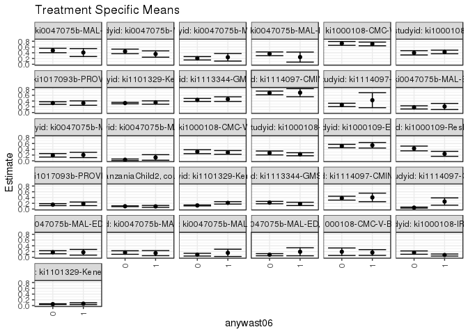

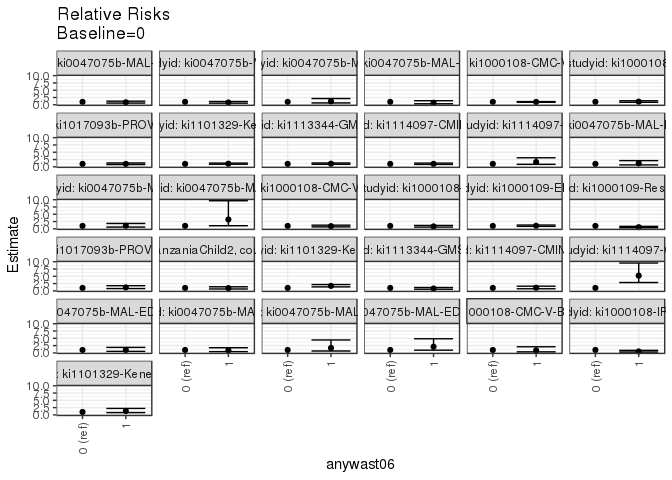

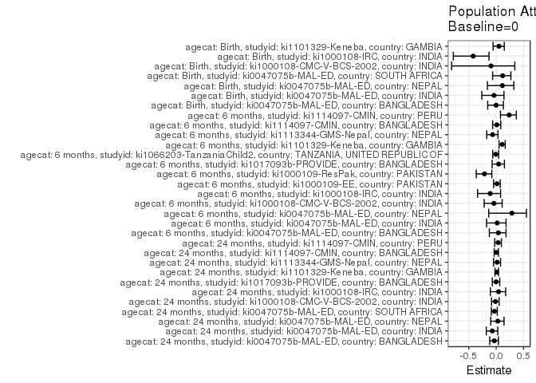

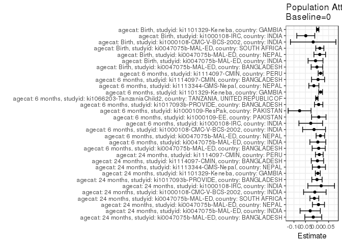

## Results Table

### Parameter: TSM

| agecat | studyid | country | intervention_level | baseline_level | estimate | ci_lower | ci_upper |
| --- | --- | --- | --- | --- | --- | --- | --- |
| Birth | ki0047075b-MAL-ED | BANGLADESH | 0 | NA | 0.1767677 | 0.1235285 | 0.2300069 |
| Birth | ki0047075b-MAL-ED | BANGLADESH | 1 | NA | 0.1754386 | 0.0765063 | 0.2743709 |
| Birth | ki0047075b-MAL-ED | INDIA | 0 | NA | 0.1666667 | 0.1056488 | 0.2276846 |
| Birth | ki0047075b-MAL-ED | INDIA | 1 | NA | 0.1451613 | 0.0572638 | 0.2330588 |
| Birth | ki0047075b-MAL-ED | NEPAL | 0 | NA | 0.0921986 | 0.0443075 | 0.1400897 |
| Birth | ki0047075b-MAL-ED | NEPAL | 1 | NA | 0.1562500 | 0.0300821 | 0.2824179 |
| Birth | ki0047075b-MAL-ED | SOUTH AFRICA | 0 | NA | 0.0913043 | 0.0540075 | 0.1286012 |
| Birth | ki0047075b-MAL-ED | SOUTH AFRICA | 1 | NA | 0.1935484 | 0.0542055 | 0.3328913 |
| Birth | ki1000108-CMC-V-BCS-2002 | INDIA | 0 | NA | 0.1944444 | 0.0644369 | 0.3244520 |
| Birth | ki1000108-CMC-V-BCS-2002 | INDIA | 1 | NA | 0.1666667 | 0.0667101 | 0.2666232 |
| Birth | ki1000108-IRC | INDIA | 0 | NA | 0.1646341 | 0.1078032 | 0.2214651 |
| Birth | ki1000108-IRC | INDIA | 1 | NA | 0.0803571 | 0.0447115 | 0.1160028 |
| Birth | ki1101329-Keneba | GAMBIA | 0 | NA | 0.0505051 | 0.0385373 | 0.0624728 |
| Birth | ki1101329-Keneba | GAMBIA | 1 | NA | 0.0669291 | 0.0361868 | 0.0976715 |
| 6 months | ki0047075b-MAL-ED | BANGLADESH | 0 | NA | 0.1793478 | 0.1237997 | 0.2348960 |
| 6 months | ki0047075b-MAL-ED | BANGLADESH | 1 | NA | 0.2105263 | 0.1044702 | 0.3165824 |
| 6 months | ki0047075b-MAL-ED | INDIA | 0 | NA | 0.1913580 | 0.1306545 | 0.2520616 |
| 6 months | ki0047075b-MAL-ED | INDIA | 1 | NA | 0.2027027 | 0.1109129 | 0.2944925 |
| 6 months | ki0047075b-MAL-ED | NEPAL | 0 | NA | 0.0362694 | 0.0098368 | 0.0627020 |
| 6 months | ki0047075b-MAL-ED | NEPAL | 1 | NA | 0.1162791 | 0.0202629 | 0.2122952 |
| 6 months | ki1000108-CMC-V-BCS-2002 | INDIA | 0 | NA | 0.3160920 | 0.2469131 | 0.3852708 |
| 6 months | ki1000108-CMC-V-BCS-2002 | INDIA | 1 | NA | 0.2916667 | 0.2272862 | 0.3560471 |
| 6 months | ki1000108-IRC | INDIA | 0 | NA | 0.2727273 | 0.2046890 | 0.3407655 |
| 6 months | ki1000108-IRC | INDIA | 1 | NA | 0.2272727 | 0.1744086 | 0.2801369 |
| 6 months | ki1000109-EE | PAKISTAN | 0 | NA | 0.5111111 | 0.4514057 | 0.5708165 |
| 6 months | ki1000109-EE | PAKISTAN | 1 | NA | 0.5392157 | 0.4423516 | 0.6360797 |
| 6 months | ki1000109-ResPak | PAKISTAN | 0 | NA | 0.4285714 | 0.3464224 | 0.5107205 |
| 6 months | ki1000109-ResPak | PAKISTAN | 1 | NA | 0.2421053 | 0.1557838 | 0.3284267 |
| 6 months | ki1017093b-PROVIDE | BANGLADESH | 0 | NA | 0.1540230 | 0.1200723 | 0.1879737 |
| 6 months | ki1017093b-PROVIDE | BANGLADESH | 1 | NA | 0.1824324 | 0.1201590 | 0.2447059 |
| 6 months | ki1066203-TanzaniaChild2 | TANZANIA, UNITED REPUBLIC OF | 0 | NA | 0.0978009 | 0.0837920 | 0.1118099 |
| 6 months | ki1066203-TanzaniaChild2 | TANZANIA, UNITED REPUBLIC OF | 1 | NA | 0.0930233 | 0.0602012 | 0.1258453 |
| 6 months | ki1101329-Keneba | GAMBIA | 0 | NA | 0.1262537 | 0.1104382 | 0.1420692 |
| 6 months | ki1101329-Keneba | GAMBIA | 1 | NA | 0.2154696 | 0.1731056 | 0.2578336 |
| 6 months | ki1113344-GMS-Nepal | NEPAL | 0 | NA | 0.2250639 | 0.1836323 | 0.2664955 |
| 6 months | ki1113344-GMS-Nepal | NEPAL | 1 | NA | 0.1802326 | 0.1227373 | 0.2377278 |
| 6 months | ki1114097-CMIN | BANGLADESH | 0 | NA | 0.3781095 | 0.3109339 | 0.4452850 |
| 6 months | ki1114097-CMIN | BANGLADESH | 1 | NA | 0.4047619 | 0.2560095 | 0.5535143 |
| 6 months | ki1114097-CMIN | PERU | 0 | NA | 0.0499139 | 0.0321925 | 0.0676354 |
| 6 months | ki1114097-CMIN | PERU | 1 | NA | 0.2608696 | 0.1338742 | 0.3878650 |
| 24 months | ki0047075b-MAL-ED | BANGLADESH | 0 | NA | 0.4785276 | 0.4016588 | 0.5553964 |
| 24 months | ki0047075b-MAL-ED | BANGLADESH | 1 | NA | 0.4081633 | 0.2702219 | 0.5461047 |
| 24 months | ki0047075b-MAL-ED | INDIA | 0 | NA | 0.4480519 | 0.3693365 | 0.5267674 |
| 24 months | ki0047075b-MAL-ED | INDIA | 1 | NA | 0.3561644 | 0.2460718 | 0.4662570 |
| 24 months | ki0047075b-MAL-ED | NEPAL | 0 | NA | 0.2085561 | 0.1501978 | 0.2669145 |
| 24 months | ki0047075b-MAL-ED | NEPAL | 1 | NA | 0.2439024 | 0.1121655 | 0.3756394 |
| 24 months | ki0047075b-MAL-ED | SOUTH AFRICA | 0 | NA | 0.3644860 | 0.2998672 | 0.4291047 |
| 24 months | ki0047075b-MAL-ED | SOUTH AFRICA | 1 | NA | 0.2500000 | 0.0763969 | 0.4236031 |
| 24 months | ki1000108-CMC-V-BCS-2002 | INDIA | 0 | NA | 0.7241379 | 0.6576380 | 0.7906378 |
| 24 months | ki1000108-CMC-V-BCS-2002 | INDIA | 1 | NA | 0.7061856 | 0.6420005 | 0.7703706 |
| 24 months | ki1000108-IRC | INDIA | 0 | NA | 0.3975904 | 0.3230503 | 0.4721304 |
| 24 months | ki1000108-IRC | INDIA | 1 | NA | 0.4279835 | 0.3656970 | 0.4902701 |
| 24 months | ki1017093b-PROVIDE | BANGLADESH | 0 | NA | 0.3294664 | 0.2850542 | 0.3738785 |
| 24 months | ki1017093b-PROVIDE | BANGLADESH | 1 | NA | 0.3287671 | 0.2525014 | 0.4050328 |
| 24 months | ki1101329-Keneba | GAMBIA | 0 | NA | 0.3284503 | 0.3028826 | 0.3540179 |
| 24 months | ki1101329-Keneba | GAMBIA | 1 | NA | 0.3483146 | 0.2911488 | 0.4054804 |
| 24 months | ki1113344-GMS-Nepal | NEPAL | 0 | NA | 0.4387464 | 0.3867808 | 0.4907121 |
| 24 months | ki1113344-GMS-Nepal | NEPAL | 1 | NA | 0.4662162 | 0.3857656 | 0.5466668 |
| 24 months | ki1114097-CMIN | BANGLADESH | 0 | NA | 0.6800000 | 0.6152169 | 0.7447831 |
| 24 months | ki1114097-CMIN | BANGLADESH | 1 | NA | 0.6904762 | 0.5503743 | 0.8305781 |
| 24 months | ki1114097-CMIN | PERU | 0 | NA | 0.2636364 | 0.2052898 | 0.3219830 |
| 24 months | ki1114097-CMIN | PERU | 1 | NA | 0.4285714 | 0.1687909 | 0.6883520 |

### Parameter: E(Y)

| agecat | studyid | country | intervention_level | baseline_level | estimate | ci_lower | ci_upper |
| --- | --- | --- | --- | --- | --- | --- | --- |
| Birth | ki0047075b-MAL-ED | BANGLADESH | NA | NA | 0.1764706 | 0.1295885 | 0.2233527 |
| Birth | ki0047075b-MAL-ED | INDIA | NA | NA | 0.1601942 | 0.1099849 | 0.2104035 |
| Birth | ki0047075b-MAL-ED | NEPAL | NA | NA | 0.1040462 | 0.0584174 | 0.1496751 |
| Birth | ki0047075b-MAL-ED | SOUTH AFRICA | NA | NA | 0.1034483 | 0.0664305 | 0.1404661 |
| Birth | ki1000108-CMC-V-BCS-2002 | INDIA | NA | NA | 0.1777778 | 0.0983474 | 0.2572081 |
| Birth | ki1000108-IRC | INDIA | NA | NA | 0.1159794 | 0.0840777 | 0.1478811 |
| Birth | ki1101329-Keneba | GAMBIA | NA | NA | 0.0532122 | 0.0420018 | 0.0644226 |
| 6 months | ki0047075b-MAL-ED | BANGLADESH | NA | NA | 0.1867220 | 0.1374205 | 0.2360234 |
| 6 months | ki0047075b-MAL-ED | INDIA | NA | NA | 0.1949153 | 0.1442678 | 0.2455627 |
| 6 months | ki0047075b-MAL-ED | NEPAL | NA | NA | 0.0508475 | 0.0227597 | 0.0789352 |
| 6 months | ki1000108-CMC-V-BCS-2002 | INDIA | NA | NA | 0.3032787 | 0.2561210 | 0.3504363 |
| 6 months | ki1000108-IRC | INDIA | NA | NA | 0.2457002 | 0.2038248 | 0.2875757 |
| 6 months | ki1000109-EE | PAKISTAN | NA | NA | 0.5188172 | 0.4679751 | 0.5696593 |
| 6 months | ki1000109-ResPak | PAKISTAN | NA | NA | 0.3531915 | 0.2919518 | 0.4144312 |
| 6 months | ki1017093b-PROVIDE | BANGLADESH | NA | NA | 0.1612350 | 0.1313580 | 0.1911120 |
| 6 months | ki1066203-TanzaniaChild2 | TANZANIA, UNITED REPUBLIC OF | NA | NA | 0.0970922 | 0.0842059 | 0.1099785 |
| 6 months | ki1101329-Keneba | GAMBIA | NA | NA | 0.1419543 | 0.1268686 | 0.1570400 |
| 6 months | ki1113344-GMS-Nepal | NEPAL | NA | NA | 0.2113677 | 0.1776128 | 0.2451225 |
| 6 months | ki1114097-CMIN | BANGLADESH | NA | NA | 0.3827160 | 0.3214780 | 0.4439541 |
| 6 months | ki1114097-CMIN | PERU | NA | NA | 0.0653907 | 0.0460250 | 0.0847565 |
| 24 months | ki0047075b-MAL-ED | BANGLADESH | NA | NA | 0.4622642 | 0.3949918 | 0.5295365 |
| 24 months | ki0047075b-MAL-ED | INDIA | NA | NA | 0.4185022 | 0.3541865 | 0.4828179 |
| 24 months | ki0047075b-MAL-ED | NEPAL | NA | NA | 0.2149123 | 0.1614774 | 0.2683472 |
| 24 months | ki0047075b-MAL-ED | SOUTH AFRICA | NA | NA | 0.3529412 | 0.2921001 | 0.4137823 |
| 24 months | ki1000108-CMC-V-BCS-2002 | INDIA | NA | NA | 0.7146739 | 0.6684741 | 0.7608737 |
| 24 months | ki1000108-IRC | INDIA | NA | NA | 0.4156479 | 0.3678270 | 0.4634689 |
| 24 months | ki1017093b-PROVIDE | BANGLADESH | NA | NA | 0.3292894 | 0.2909105 | 0.3676684 |
| 24 months | ki1101329-Keneba | GAMBIA | NA | NA | 0.3318414 | 0.3084975 | 0.3551853 |
| 24 months | ki1113344-GMS-Nepal | NEPAL | NA | NA | 0.4468938 | 0.4032281 | 0.4905594 |
| 24 months | ki1114097-CMIN | BANGLADESH | NA | NA | 0.6818182 | 0.6230135 | 0.7406228 |
| 24 months | ki1114097-CMIN | PERU | NA | NA | 0.2735043 | 0.2162683 | 0.3307402 |

### Parameter: RR

| agecat | studyid | country | intervention_level | baseline_level | estimate | ci_lower | ci_upper |
| --- | --- | --- | --- | --- | --- | --- | --- |
| Birth | ki0047075b-MAL-ED | BANGLADESH | 0 | 0 | 1.0000000 | 1.0000000 | 1.0000000 |
| Birth | ki0047075b-MAL-ED | BANGLADESH | 1 | 0 | 0.9924812 | 0.5236923 | 1.8809116 |
| Birth | ki0047075b-MAL-ED | INDIA | 0 | 0 | 1.0000000 | 1.0000000 | 1.0000000 |
| Birth | ki0047075b-MAL-ED | INDIA | 1 | 0 | 0.8709677 | 0.4292393 | 1.7672773 |
| Birth | ki0047075b-MAL-ED | NEPAL | 0 | 0 | 1.0000000 | 1.0000000 | 1.0000000 |
| Birth | ki0047075b-MAL-ED | NEPAL | 1 | 0 | 1.6947115 | 0.6488162 | 4.4265957 |
| Birth | ki0047075b-MAL-ED | SOUTH AFRICA | 0 | 0 | 1.0000000 | 1.0000000 | 1.0000000 |
| Birth | ki0047075b-MAL-ED | SOUTH AFRICA | 1 | 0 | 2.1198157 | 0.9264235 | 4.8505013 |
| Birth | ki1000108-CMC-V-BCS-2002 | INDIA | 0 | 0 | 1.0000000 | 1.0000000 | 1.0000000 |
| Birth | ki1000108-CMC-V-BCS-2002 | INDIA | 1 | 0 | 0.8571429 | 0.3491232 | 2.1043973 |
| Birth | ki1000108-IRC | INDIA | 0 | 0 | 1.0000000 | 1.0000000 | 1.0000000 |
| Birth | ki1000108-IRC | INDIA | 1 | 0 | 0.4880952 | 0.2782256 | 0.8562726 |
| Birth | ki1101329-Keneba | GAMBIA | 0 | 0 | 1.0000000 | 1.0000000 | 1.0000000 |
| Birth | ki1101329-Keneba | GAMBIA | 1 | 0 | 1.3251968 | 0.7903437 | 2.2220037 |
| 6 months | ki0047075b-MAL-ED | BANGLADESH | 0 | 0 | 1.0000000 | 1.0000000 | 1.0000000 |
| 6 months | ki0047075b-MAL-ED | BANGLADESH | 1 | 0 | 1.1738437 | 0.6498080 | 2.1204865 |
| 6 months | ki0047075b-MAL-ED | INDIA | 0 | 0 | 1.0000000 | 1.0000000 | 1.0000000 |
| 6 months | ki0047075b-MAL-ED | INDIA | 1 | 0 | 1.0592851 | 0.6093913 | 1.8413210 |
| 6 months | ki0047075b-MAL-ED | NEPAL | 0 | 0 | 1.0000000 | 1.0000000 | 1.0000000 |
| 6 months | ki0047075b-MAL-ED | NEPAL | 1 | 0 | 3.2059801 | 1.0657387 | 9.6443043 |
| 6 months | ki1000108-CMC-V-BCS-2002 | INDIA | 0 | 0 | 1.0000000 | 1.0000000 | 1.0000000 |
| 6 months | ki1000108-CMC-V-BCS-2002 | INDIA | 1 | 0 | 0.9227273 | 0.6762036 | 1.2591262 |
| 6 months | ki1000108-IRC | INDIA | 0 | 0 | 1.0000000 | 1.0000000 | 1.0000000 |
| 6 months | ki1000108-IRC | INDIA | 1 | 0 | 0.8333333 | 0.5924970 | 1.1720640 |
| 6 months | ki1000109-EE | PAKISTAN | 0 | 0 | 1.0000000 | 1.0000000 | 1.0000000 |
| 6 months | ki1000109-EE | PAKISTAN | 1 | 0 | 1.0549872 | 0.8515040 | 1.3070967 |
| 6 months | ki1000109-ResPak | PAKISTAN | 0 | 0 | 1.0000000 | 1.0000000 | 1.0000000 |
| 6 months | ki1000109-ResPak | PAKISTAN | 1 | 0 | 0.5649123 | 0.3768573 | 0.8468083 |
| 6 months | ki1017093b-PROVIDE | BANGLADESH | 0 | 0 | 1.0000000 | 1.0000000 | 1.0000000 |
| 6 months | ki1017093b-PROVIDE | BANGLADESH | 1 | 0 | 1.1844494 | 0.7889465 | 1.7782198 |
| 6 months | ki1066203-TanzaniaChild2 | TANZANIA, UNITED REPUBLIC OF | 0 | 0 | 1.0000000 | 1.0000000 | 1.0000000 |
| 6 months | ki1066203-TanzaniaChild2 | TANZANIA, UNITED REPUBLIC OF | 1 | 0 | 0.9511490 | 0.6499315 | 1.3919690 |
| 6 months | ki1101329-Keneba | GAMBIA | 0 | 0 | 1.0000000 | 1.0000000 | 1.0000000 |
| 6 months | ki1101329-Keneba | GAMBIA | 1 | 0 | 1.7066402 | 1.3517485 | 2.1547061 |
| 6 months | ki1113344-GMS-Nepal | NEPAL | 0 | 0 | 1.0000000 | 1.0000000 | 1.0000000 |
| 6 months | ki1113344-GMS-Nepal | NEPAL | 1 | 0 | 0.8008060 | 0.5540791 | 1.1573984 |
| 6 months | ki1114097-CMIN | BANGLADESH | 0 | 0 | 1.0000000 | 1.0000000 | 1.0000000 |
| 6 months | ki1114097-CMIN | BANGLADESH | 1 | 0 | 1.0704887 | 0.7117126 | 1.6101249 |
| 6 months | ki1114097-CMIN | PERU | 0 | 0 | 1.0000000 | 1.0000000 | 1.0000000 |
| 6 months | ki1114097-CMIN | PERU | 1 | 0 | 5.2263868 | 2.8610531 | 9.5472255 |
| 24 months | ki0047075b-MAL-ED | BANGLADESH | 0 | 0 | 1.0000000 | 1.0000000 | 1.0000000 |
| 24 months | ki0047075b-MAL-ED | BANGLADESH | 1 | 0 | 0.8529566 | 0.5867027 | 1.2400403 |
| 24 months | ki0047075b-MAL-ED | INDIA | 0 | 0 | 1.0000000 | 1.0000000 | 1.0000000 |
| 24 months | ki0047075b-MAL-ED | INDIA | 1 | 0 | 0.7949176 | 0.5570721 | 1.1343127 |
| 24 months | ki0047075b-MAL-ED | NEPAL | 0 | 0 | 1.0000000 | 1.0000000 | 1.0000000 |
| 24 months | ki0047075b-MAL-ED | NEPAL | 1 | 0 | 1.1694809 | 0.6365185 | 2.1486974 |
| 24 months | ki0047075b-MAL-ED | SOUTH AFRICA | 0 | 0 | 1.0000000 | 1.0000000 | 1.0000000 |
| 24 months | ki0047075b-MAL-ED | SOUTH AFRICA | 1 | 0 | 0.6858974 | 0.3349703 | 1.4044687 |
| 24 months | ki1000108-CMC-V-BCS-2002 | INDIA | 0 | 0 | 1.0000000 | 1.0000000 | 1.0000000 |
| 24 months | ki1000108-CMC-V-BCS-2002 | INDIA | 1 | 0 | 0.9752086 | 0.8570061 | 1.1097143 |
| 24 months | ki1000108-IRC | INDIA | 0 | 0 | 1.0000000 | 1.0000000 | 1.0000000 |
| 24 months | ki1000108-IRC | INDIA | 1 | 0 | 1.0764434 | 0.8490181 | 1.3647888 |
| 24 months | ki1017093b-PROVIDE | BANGLADESH | 0 | 0 | 1.0000000 | 1.0000000 | 1.0000000 |
| 24 months | ki1017093b-PROVIDE | BANGLADESH | 1 | 0 | 0.9978777 | 0.7630575 | 1.3049604 |
| 24 months | ki1101329-Keneba | GAMBIA | 0 | 0 | 1.0000000 | 1.0000000 | 1.0000000 |
| 24 months | ki1101329-Keneba | GAMBIA | 1 | 0 | 1.0604790 | 0.8843296 | 1.2717156 |
| 24 months | ki1113344-GMS-Nepal | NEPAL | 0 | 0 | 1.0000000 | 1.0000000 | 1.0000000 |
| 24 months | ki1113344-GMS-Nepal | NEPAL | 1 | 0 | 1.0626097 | 0.8619398 | 1.3099979 |
| 24 months | ki1114097-CMIN | BANGLADESH | 0 | 0 | 1.0000000 | 1.0000000 | 1.0000000 |
| 24 months | ki1114097-CMIN | BANGLADESH | 1 | 0 | 1.0154062 | 0.8115007 | 1.2705469 |
| 24 months | ki1114097-CMIN | PERU | 0 | 0 | 1.0000000 | 1.0000000 | 1.0000000 |
| 24 months | ki1114097-CMIN | PERU | 1 | 0 | 1.6256158 | 0.8526495 | 3.0993118 |

### Parameter: PAR

| agecat | studyid | country | intervention_level | baseline_level | estimate | ci_lower | ci_upper |
| --- | --- | --- | --- | --- | --- | --- | --- |
| Birth | ki0047075b-MAL-ED | BANGLADESH | 0 | NA | -0.0002971 | -0.0254102 | 0.0248160 |
| Birth | ki0047075b-MAL-ED | INDIA | 0 | NA | -0.0064725 | -0.0387049 | 0.0257599 |
| Birth | ki0047075b-MAL-ED | NEPAL | 0 | NA | 0.0118477 | -0.0133896 | 0.0370850 |
| Birth | ki0047075b-MAL-ED | SOUTH AFRICA | 0 | NA | 0.0121439 | -0.0054544 | 0.0297423 |
| Birth | ki1000108-CMC-V-BCS-2002 | INDIA | 0 | NA | -0.0166667 | -0.1151023 | 0.0817690 |
| Birth | ki1000108-IRC | INDIA | 0 | NA | -0.0486548 | -0.0876056 | -0.0097039 |
| Birth | ki1101329-Keneba | GAMBIA | 0 | NA | 0.0027071 | -0.0027390 | 0.0081533 |
| 6 months | ki0047075b-MAL-ED | BANGLADESH | 0 | NA | 0.0073742 | -0.0209915 | 0.0357399 |
| 6 months | ki0047075b-MAL-ED | INDIA | 0 | NA | 0.0035572 | -0.0309555 | 0.0380700 |
| 6 months | ki0047075b-MAL-ED | NEPAL | 0 | NA | 0.0145780 | -0.0039919 | 0.0331480 |
| 6 months | ki1000108-CMC-V-BCS-2002 | INDIA | 0 | NA | -0.0128133 | -0.0624037 | 0.0367771 |
| 6 months | ki1000108-IRC | INDIA | 0 | NA | -0.0270270 | -0.0783042 | 0.0242502 |
| 6 months | ki1000109-EE | PAKISTAN | 0 | NA | 0.0077061 | -0.0235195 | 0.0389317 |
| 6 months | ki1000109-ResPak | PAKISTAN | 0 | NA | -0.0753799 | -0.1249586 | -0.0258013 |
| 6 months | ki1017093b-PROVIDE | BANGLADESH | 0 | NA | 0.0072120 | -0.0108215 | 0.0252455 |
| 6 months | ki1066203-TanzaniaChild2 | TANZANIA, UNITED REPUBLIC OF | 0 | NA | -0.0007088 | -0.0060034 | 0.0045858 |
| 6 months | ki1101329-Keneba | GAMBIA | 0 | NA | 0.0157006 | 0.0076082 | 0.0237930 |
| 6 months | ki1113344-GMS-Nepal | NEPAL | 0 | NA | -0.0136963 | -0.0354141 | 0.0080216 |
| 6 months | ki1114097-CMIN | BANGLADESH | 0 | NA | 0.0046066 | -0.0236323 | 0.0328455 |
| 6 months | ki1114097-CMIN | PERU | 0 | NA | 0.0154768 | 0.0051297 | 0.0258239 |
| 24 months | ki0047075b-MAL-ED | BANGLADESH | 0 | NA | -0.0162635 | -0.0529811 | 0.0204542 |
| 24 months | ki0047075b-MAL-ED | INDIA | 0 | NA | -0.0295497 | -0.0734309 | 0.0143314 |
| 24 months | ki0047075b-MAL-ED | NEPAL | 0 | NA | 0.0063561 | -0.0196139 | 0.0323262 |
| 24 months | ki0047075b-MAL-ED | SOUTH AFRICA | 0 | NA | -0.0115448 | -0.0307331 | 0.0076435 |
| 24 months | ki1000108-CMC-V-BCS-2002 | INDIA | 0 | NA | -0.0094640 | -0.0581955 | 0.0392675 |
| 24 months | ki1000108-IRC | INDIA | 0 | NA | 0.0180576 | -0.0396735 | 0.0757886 |
| 24 months | ki1017093b-PROVIDE | BANGLADESH | 0 | NA | -0.0001769 | -0.0225083 | 0.0221544 |
| 24 months | ki1101329-Keneba | GAMBIA | 0 | NA | 0.0033912 | -0.0073060 | 0.0140883 |
| 24 months | ki1113344-GMS-Nepal | NEPAL | 0 | NA | 0.0081473 | -0.0202800 | 0.0365747 |
| 24 months | ki1114097-CMIN | BANGLADESH | 0 | NA | 0.0018182 | -0.0249753 | 0.0286117 |
| 24 months | ki1114097-CMIN | PERU | 0 | NA | 0.0098679 | -0.0068348 | 0.0265706 |

### Parameter: PAF

| agecat | studyid | country | intervention_level | baseline_level | estimate | ci_lower | ci_upper |
| --- | --- | --- | --- | --- | --- | --- | --- |
| Birth | ki0047075b-MAL-ED | BANGLADESH | 0 | NA | -0.0016835 | -0.1545956 | 0.1309772 |
| Birth | ki0047075b-MAL-ED | INDIA | 0 | NA | -0.0404040 | -0.2620941 | 0.1423456 |
| Birth | ki0047075b-MAL-ED | NEPAL | 0 | NA | 0.1138692 | -0.1597337 | 0.3229240 |
| Birth | ki0047075b-MAL-ED | SOUTH AFRICA | 0 | NA | 0.1173913 | -0.0651687 | 0.2686622 |
| Birth | ki1000108-CMC-V-BCS-2002 | INDIA | 0 | NA | -0.0937500 | -0.8131914 | 0.3402301 |
| Birth | ki1000108-IRC | INDIA | 0 | NA | -0.4195122 | -0.7824186 | -0.1304948 |
| Birth | ki1101329-Keneba | GAMBIA | 0 | NA | 0.0508746 | -0.0566354 | 0.1474457 |
| 6 months | ki0047075b-MAL-ED | BANGLADESH | 0 | NA | 0.0394928 | -0.1248594 | 0.1798316 |
| 6 months | ki0047075b-MAL-ED | INDIA | 0 | NA | 0.0182501 | -0.1757476 | 0.1802384 |
| 6 months | ki0047075b-MAL-ED | NEPAL | 0 | NA | 0.2867012 | -0.1360592 | 0.5521403 |
| 6 months | ki1000108-CMC-V-BCS-2002 | INDIA | 0 | NA | -0.0422491 | -0.2192736 | 0.1090734 |
| 6 months | ki1000108-IRC | INDIA | 0 | NA | -0.1100000 | -0.3393257 | 0.0800595 |
| 6 months | ki1000109-EE | PAKISTAN | 0 | NA | 0.0148532 | -0.0472305 | 0.0732563 |
| 6 months | ki1000109-ResPak | PAKISTAN | 0 | NA | -0.2134251 | -0.3640121 | -0.0794629 |
| 6 months | ki1017093b-PROVIDE | BANGLADESH | 0 | NA | 0.0447298 | -0.0737083 | 0.1501032 |
| 6 months | ki1066203-TanzaniaChild2 | TANZANIA, UNITED REPUBLIC OF | 0 | NA | -0.0072999 | -0.0633275 | 0.0457756 |
| 6 months | ki1101329-Keneba | GAMBIA | 0 | NA | 0.1106033 | 0.0526481 | 0.1650131 |
| 6 months | ki1113344-GMS-Nepal | NEPAL | 0 | NA | -0.0647983 | -0.1724217 | 0.0329457 |
| 6 months | ki1114097-CMIN | BANGLADESH | 0 | NA | 0.0120366 | -0.0645803 | 0.0831394 |
| 6 months | ki1114097-CMIN | PERU | 0 | NA | 0.2366819 | 0.0785640 | 0.3676669 |
| 24 months | ki0047075b-MAL-ED | BANGLADESH | 0 | NA | -0.0351822 | -0.1178778 | 0.0413960 |
| 24 months | ki0047075b-MAL-ED | INDIA | 0 | NA | -0.0706083 | -0.1811022 | 0.0295486 |
| 24 months | ki0047075b-MAL-ED | NEPAL | 0 | NA | 0.0295755 | -0.0989918 | 0.1431021 |
| 24 months | ki0047075b-MAL-ED | SOUTH AFRICA | 0 | NA | -0.0327103 | -0.0885726 | 0.0202854 |
| 24 months | ki1000108-CMC-V-BCS-2002 | INDIA | 0 | NA | -0.0132424 | -0.0837996 | 0.0527213 |
| 24 months | ki1000108-IRC | INDIA | 0 | NA | 0.0434444 | -0.1060775 | 0.1727536 |
| 24 months | ki1017093b-PROVIDE | BANGLADESH | 0 | NA | -0.0005373 | -0.0707053 | 0.0650322 |
| 24 months | ki1101329-Keneba | GAMBIA | 0 | NA | 0.0102192 | -0.0225471 | 0.0419356 |
| 24 months | ki1113344-GMS-Nepal | NEPAL | 0 | NA | 0.0182311 | -0.0475016 | 0.0798389 |
| 24 months | ki1114097-CMIN | BANGLADESH | 0 | NA | 0.0026667 | -0.0374173 | 0.0412018 |
| 24 months | ki1114097-CMIN | PERU | 0 | NA | 0.0360795 | -0.0268293 | 0.0951343 |